# ICU Survival

The data *ICU* has information for a sample of 200 patients who were part of a larger study conducted in a hospital’s Intensive Care Unit (ICU). Since an ICU often deals with serious, life-threatening cases, a key variable to study is patient survival, which is coded in the *Survive* variable as 1 if the patient lived to be discharged and 0 if the patient died. Among the possible predictors of this binary survival response are the following (all recorded at the time of admission):

- *Age* = age (in years)
- *AgeGroup* = 1 if under 50, 2 if 50-69, 3 if 70+
- *Sex* = 1 if female, 0 if male
- *Infection* = 1 if infection is suspected, 2 if no infection
- *SysBP* = systolic blood pressure (in mm Hg)
- *Pulse* = heart rate (beats per minute)
- *Emergency* = 1 if emergency admission, 0 otherwise

Let’s load the data and look first at the relationship between survival and the age of the patient. Because many of the dots overlap, we’ll need to jitter both variables to make it possible to see many of them.

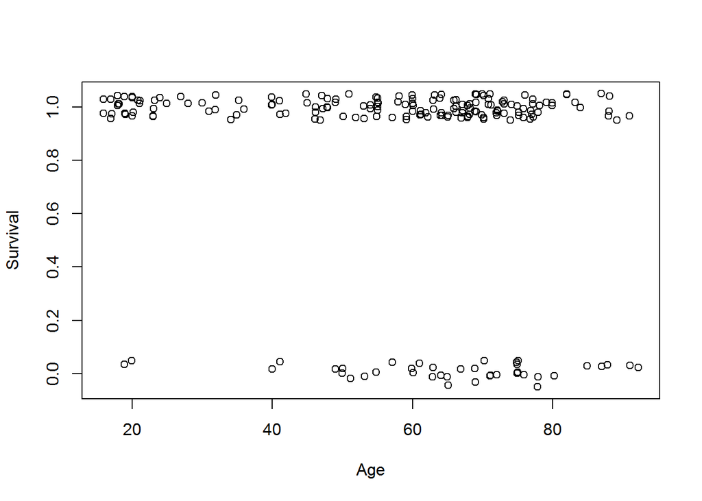

```r
library(Stat2Data)
data("ICU")
data("MedGPA")
plot(jitter(Survive, amount=0.05) ~ jitter(Age, amount=0.2), data=ICU, xlab="Age", ylab="Survival")
```

We see that overall most patients survive, but that there seem to be more who die among older patients. Let’s fit a logistic regression model:

```r
(m1 <- glm(Survive ~ Age, data=ICU, family="binomial"))
```

```
##
## Call:  glm(formula = Survive ~ Age, family = "binomial", data = ICU)
##
## Coefficients:
## (Intercept)          Age
##     3.05851     -0.02754
##
## Degrees of Freedom: 199 Total (i.e. Null);  198 Residual
## Null Deviance:       200.2
## Residual Deviance: 192.3     AIC: 196.3
```

The fitted model gives a linear equation for the logit (that is, log(odds)):
$$log(odds(Survive)) = 3.059 - 0.0275 \times Age.$$
The fitted model can also be written in terms of a formula for the odds of survival or as a logistic model for the probability of survival:
$$odds(Survive) = e^{3.059 - 0.0275 Age}$$
$$P(Survive) = \frac{e^{3.059 - 0.0275 Age}}{1+e^{3.059 - 0.0275 Age}}.$$
To visualize the relationship between *Survive* and *Age*, we can add the logistic curve to the scatterplot:

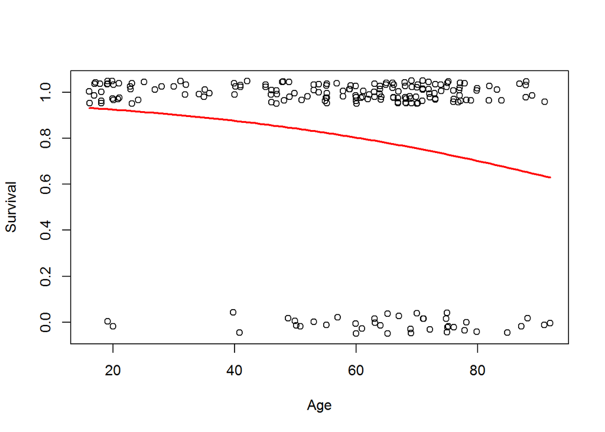

```r
plot(jitter(Survive, amount=0.05) ~ jitter(Age, amount=0.2), data=ICU, xlab="Age", ylab="Survival")
B0=coef(m1)[1]
B1=coef(m1)[2]
curve(exp(B0+B1*x)/(1+exp(B0+B1*x)), add=T, col="red", lwd=2)
```